# Pneumonia X-Ray Images

[figure not shown]

Adapted version of Paul Mooney's 'Chest X-Ray Images (Pneumonia)' dataset, where the amount of observations for training and validation purposes was redistributed to allow for a more balanced machine learning exercise.

### Importing Necessary packages

```python
import numpy as np
import pandas as pd
import matplotlib.pyplot as plt
import seaborn as sns
import os

import matplotlib.image as mimg
import cv2
from keras.preprocessing.image import ImageDataGenerator
from keras.applications import VGG16
from keras.models import Model
from keras.layers import Dense, Flatten
from keras.optimizers import Adam
from sklearn.metrics import classification_report, roc_curve,confusion_matrix
from sklearn.model_selection import train_test_split
import tensorflow as tf
from tensorflow.keras.models import Sequential
from tensorflow.keras.layers import Conv2D, MaxPooling2D,GlobalAveragePooling2D, Flatten, Dense, Dropout, BatchNormalization
from tensorflow.keras.callbacks import ModelCheckpoint, EarlyStopping, ReduceLROnPlateau
from tensorflow.keras.optimizers import Adam
import tensorflow as tf
from tensorflow.keras.callbacks import EarlyStopping
```

### Creating a DataFrame

```python
def create_data(normal_path, pneumonia_path):
    data = []
    for filename in os.listdir(normal_path):
        data.append((os.path.join(normal_path, filename), 0))
    for filename in os.listdir(pneumonia_path):
        data.append((os.path.join(pneumonia_path, filename), 1))
    data_df = pd.DataFrame(data, columns=['image_path', 'label'])
    return data_df.sample(frac=1).reset_index(drop=True)

train_data = create_data("C:/Users/Soundarya/Desktop/chestxray/train/normal", "C:/Users/Soundarya/Desktop/chestxray/train/opacity")
val_data = create_data("C:/Users/Soundarya/Desktop/chestxray/test/normal", "C:/Users/Soundarya/Desktop/chestxray/test/opacity")
test_data = create_data("C:/Users/Soundarya/Desktop/chestxray/val/normal", "C:/Users/Soundarya/Desktop/chestxray/val/opacity")

print("Train Data {}".format(train_data.shape))
print("Validation Data {}".format(val_data.shape))
print("Test Data {}".format(test_data.shape))
```

```
Train Data (4192, 2)
Validation Data (624, 2)
Test Data (1040, 2)
```

```python
train_data.head()
```

|  | image_path | label |
| --- | --- | --- |
| 0 | C:/Users/Soundarya/Desktop/chestxray/train/opa... | 1 |
| 1 | C:/Users/Soundarya/Desktop/chestxray/train/nor... | 0 |
| 2 | C:/Users/Soundarya/Desktop/chestxray/train/opa... | 1 |
| 3 | C:/Users/Soundarya/Desktop/chestxray/train/opa... | 1 |
| 4 | C:/Users/Soundarya/Desktop/chestxray/train/opa... | 1 |

### Basic Analysis

```python
Name = {0:'Normal', 1:'Opacity'}
train_data['name'] = train_data.label.map(Name)
```

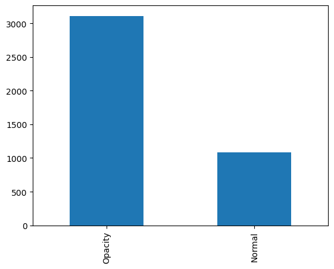

```python
train_data.name.value_counts().plot(kind="bar")
```

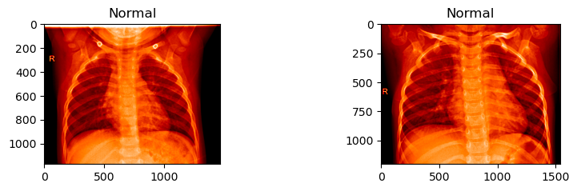

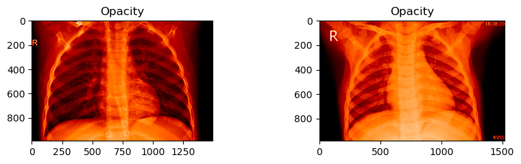

```python
def vis(images):
    fig = plt.figure(figsize=(10,5))
    for i,path in enumerate(images):
        fig.add_subplot(2, 2, i+1)
        img = mimg.imread(path)
        plt.imshow(img,cmap="gist_heat")
        plt.title(train_data[train_data.image_path == path].name.values[0])

for i in range(2):
    images = train_data[train_data.label == i].image_path
    images = np.random.choice(images , 2)
    vis(images)
```

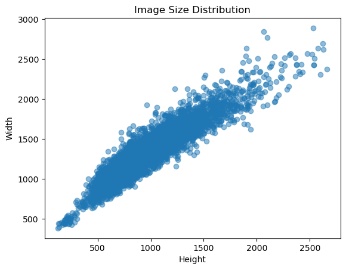

```python
image_sizes = [mimg.imread(img_path).shape[:2] for img_path in train_data['image_path']]
heights, widths = zip(*image_sizes)

plt.scatter(heights, widths, alpha=0.5)
plt.title('Image Size Distribution')
plt.xlabel('Height')
plt.ylabel('Width')
plt.show()
```

### Preprocessing

```python
BATCH_SIZE = 32
IMG_SHAPE  = 224

train_image_gen = ImageDataGenerator(rescale=1./255,
                                     width_shift_range=0.1,
                                     height_shift_range=0.1,
                                     brightness_range=[0.2,1.0],
                                     zoom_range=0.2,
                                     horizontal_flip=True,
                                     fill_mode='nearest')

train_gen = train_image_gen.flow_from_dataframe(train_data,
                                              x_col='image_path',
                                              y_col='name',
                                              class_mode='binary',
                                              batch_size=BATCH_SIZE,
                                              shuffle=True,
                                              target_size=(IMG_SHAPE,IMG_SHAPE))
```

```
Found 4192 validated image filenames belonging to 2 classes.
```

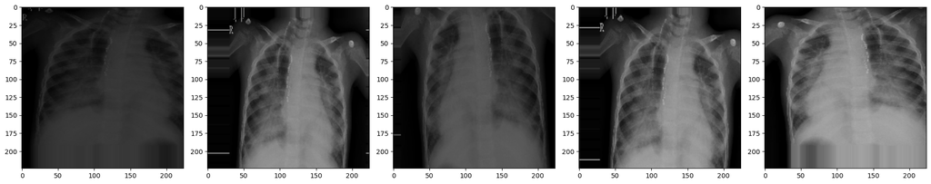

```python
aug_img = [train_gen[0][0][2] for i in range(5)]
fig, axes = plt.subplots(1, 5, figsize=(20,20))
axes = axes.flatten()
for img, ax in zip(aug_img, axes):
    ax.imshow(img)
plt.tight_layout()
plt.show()
```

```python
from tensorflow.keras.utils import to_categorical

def process_data(data):
    lb = to_categorical(data.label, dtype=int)
    data = data.reset_index().drop(labels='index', axis=1)
    y_labels = pd.DataFrame(lb).add_prefix('label_')
    return pd.concat([data, y_labels], axis=1)

train_data = process_data(train_data)
val_data = process_data(val_data)

print("Training set has {} samples".format(train_data.shape[0]))
print("Validation set has {} samples".format(val_data.shape[0]))
```

```
Training set has 4192 samples
Validation set has 624 samples
```

```python
BATCH_SIZE = 32
IMG_SHAPE = 224
EPOCHS = 20

def create_gen(data, image_gen_args):
    image_gen = ImageDataGenerator(**image_gen_args)
    return image_gen.flow_from_dataframe(data,
                                         x_col='image_path',
                                         y_col=[f'label_{x}' for x in np.arange(2)],
                                         class_mode='raw',
                                         batch_size=BATCH_SIZE,
                                         target_size=(IMG_SHAPE, IMG_SHAPE))

def gen():
    train_gen_args = {'rescale': 1./255,
                      'width_shift_range': 0.1,
                      'height_shift_range': 0.1,
                      'brightness_range': [0.2, 1.0],
                      'zoom_range': 0.2,
                      'horizontal_flip': True,
                      'vertical_flip': True,
                      'fill_mode': 'nearest'}

    val_gen_args = {'rescale': 1./255}

    train_gen = create_gen(train_data, train_gen_args)
    val_gen = create_gen(val_data, val_gen_args)

    return train_gen, val_gen
```

```python
from sklearn.utils import class_weight

class_weights = class_weight.compute_class_weight('balanced', classes=np.unique(train_data['label']), y=train_data.label)
class_weights = dict(enumerate(class_weights))
print(class_weights)
```

```
{0: 1.9371534195933457, 1: 0.6739549839228296}
```

### VGG-16

VGG16 is a convolutional neural network architecture named after the Visual Geometry Group from Oxford, who developed it. It was used to win the ILSVRC (ImageNet) competition in 2014.

- **Input Layer:** Takes an input image of a fixed size (224 x 224 x 3).
- **Convolutional Layers:** Contains 16 weight layers - 13 convolutional layers and 3 fully connected layers.
- **Convolutional Blocks:** Organized into five blocks, each containing two or three convolutional layers followed by a max-pooling layer.
- **Fully Connected Layers:** Three fully connected layers of 4096, 4096, and 1000 nodes, respectively. The final layer has a softmax activation function, outputting 1000 probabilities corresponding to the 1000 ImageNet classes.
- **Activation Function:** ReLU (Rectified Linear Activation) is used after each convolution operation.
- **Total Parameters:** Around 138 million parameters.

```python
from tensorflow.keras.applications.vgg16 import VGG16

base = VGG16(weights = 'imagenet', include_top = False, input_shape = (224, 224, 3))
tf.keras.backend.clear_session()

for layer in base.layers:
    layer.trainable = False

vgg_model = Sequential()
vgg_model.add(base)
vgg_model.add(GlobalAveragePooling2D())
vgg_model.add(BatchNormalization())
vgg_model.add(Dense(256, activation='relu'))
vgg_model.add(Dropout(0.5))
vgg_model.add(BatchNormalization())
vgg_model.add(Dense(128, activation='relu'))
vgg_model.add(Dropout(0.5))
vgg_model.add(Dense(2, activation='softmax'))

vgg_model.summary()
```

```
Model: "sequential"
_________________________________________________________________
 Layer (type)                Output Shape              Param #
=================================================================
 vgg16 (Functional)          (None, 7, 7, 512)         14714688

 global_average_pooling2d (G  (None, 512)              0
 lobalAveragePooling2D)

 batch_normalization (BatchN  (None, 512)              2048
 ormalization)

 dense (Dense)               (None, 256)               131328

 dropout (Dropout)           (None, 256)               0

 batch_normalization_1 (Batc  (None, 256)              1024
 hNormalization)

 dense_1 (Dense)             (None, 128)               32896

 dropout_1 (Dropout)         (None, 128)               0

 dense_2 (Dense)             (None, 2)                 258

=================================================================
Total params: 14,882,242
Trainable params: 166,018
Non-trainable params: 14,716,224
_________________________________________________________________
```

```python
from tensorflow.keras.callbacks import EarlyStopping
train_gen, val_gen = gen()

optm = Adam(lr=0.0001)
vgg_model.compile(loss='binary_crossentropy', optimizer=optm,
                  metrics=['accuracy'])

EarlyStopping = EarlyStopping(monitor='val_loss',
                              min_delta=.0001,
                              patience=3,
                              verbose=1,
                              mode='auto',
                              baseline=None,
                              restore_best_weights=True)

model_save = ModelCheckpoint('./vgg16_model.h5',
                             save_best_only = True,
                             save_weights_only = False,
                             monitor = 'val_loss',
                             mode = 'min', verbose = 1)


vgg_history = vgg_model.fit(train_gen,
                             steps_per_epoch = train_gen.samples // BATCH_SIZE,
                             epochs = 10,
                             validation_data = val_gen,
                             callbacks=[EarlyStopping, model_save],
                             class_weight = class_weights)
```

```
Found 4192 validated image filenames.
Found 624 validated image filenames.
```

```
WARNING:absl:`lr` is deprecated, please use `learning_rate` instead, or use the legacy optimizer, e.g.,tf.keras.optimizers.legacy.Adam.
```

```
Epoch 1: val_loss improved from inf to 0.58525, saving model to .\vgg16_model.h5
Epoch 2: val_loss improved from 0.58525 to 0.42788, saving model to .\vgg16_model.h5
Epoch 3: val_loss improved from 0.42788 to 0.40089, saving model to .\vgg16_model.h5
Epoch 4: val_loss improved from 0.40089 to 0.34562, saving model to .\vgg16_model.h5
Epoch 5: val_loss did not improve from 0.34562
Epoch 6: val_loss improved from 0.34562 to 0.32731, saving model to .\vgg16_model.h5
Epoch 7: val_loss did not improve from 0.32731
Epoch 8: val_loss did not improve from 0.32731

Epoch 9: val_loss did not improve from 0.32731
Epoch 9: early stopping
```

```python
def plot(history):
    epochs_range = range(len(history.history['accuracy']))
    metrics = [('accuracy', 'Training and Validation Accuracy'), ('loss', 'Training and Validation Loss')]

    plt.figure(figsize=(10, 5))

    for i, (metric, title) in enumerate(metrics, 1):
        plt.subplot(1, 2, i)
        plt.plot(epochs_range, history.history[metric], label=f'Training {metric.capitalize()}')
        plt.plot(epochs_range, history.history[f'val_{metric}'], label=f'Validation {metric.capitalize()}')
        plt.legend(loc='lower right' if metric == 'accuracy' else 'upper right')
        plt.title(title)

    plt.show()
```

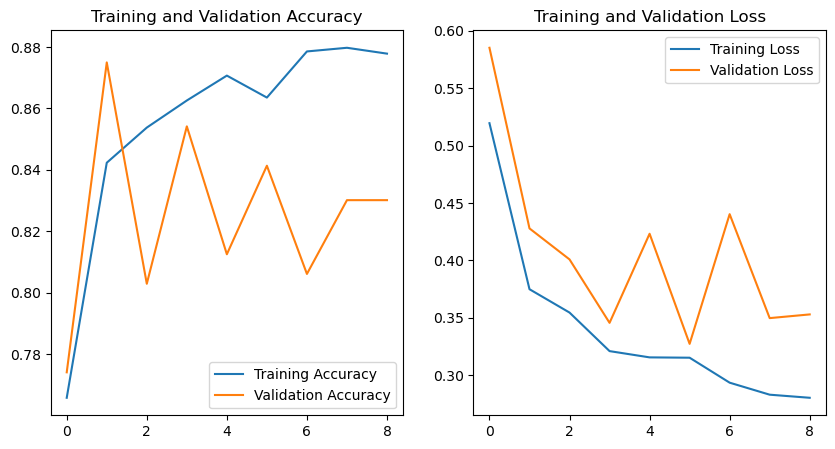

```python
plot(vgg_history)
```

```python
print(vgg_history.history['val_accuracy'][-3])
print(vgg_history.history['val_loss'][-3])
```

```
0.8060897588729858
0.4402965009212494
```

```python
from PIL import Image
def predict(image_path, model):
    im = cv2.imread(image_path)
    test_image = np.asarray(im)
    processed_test_image = process_image(test_image)
    processed_test_image = np.expand_dims(processed_test_image, axis = 0)

    ps = model.predict(processed_test_image);
    return ps

def process_image(image):
    image = tf.cast(image , tf.float32)
    image = tf.image.resize(image , (224 , 224))
    image = image/255
    image = image.numpy()
    return image
```

```
              precision    recall  f1-score   support

           0       0.63      0.96      0.76       267
           1       0.98      0.81      0.89       773

    accuracy                           0.85      1040
   macro avg       0.81      0.88      0.82      1040
weighted avg       0.89      0.85      0.85      1040
```

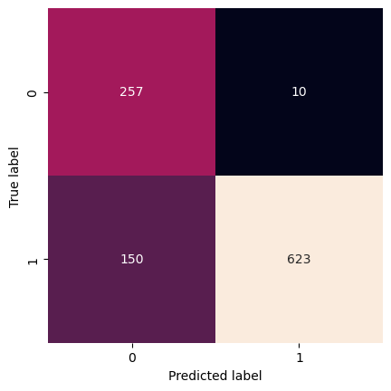

```python
vgg_pred =[]
for image in test_data.image_path:
    vgg_pred.append(predict(image , vgg_model))

final_vgg_pred  = np.argmax(vgg_pred , axis=-1)
actual_label = test_data['label']

print(classification_report(actual_label, final_vgg_pred))
matrix=confusion_matrix(actual_label, final_vgg_pred)
sns.heatmap(matrix,square=True, annot=True, fmt='d', cbar=False,
            xticklabels=['0', '1'],
            yticklabels=['0', '1'])
plt.xlabel('Predicted label')
plt.ylabel('True label');
```

### DenseNet169

**DenseNet169 (Densely Connected Convolutional Networks)**

- **Input Layer:** Typically takes an input image of size (224 x 224 x 3).
- **Dense Blocks:** Contains several densely connected blocks. Each layer within these blocks receives the feature-maps of all preceding layers, concatenating them channel-wise.
- **Growth Rate:** A hyperparameter that defines the number of output feature-maps of each internal layer. It controls how much new information each layer contributes to the global state.
- **Bottleneck Layers:** Used to reduce the input dimensionality before expensive convolution operations, thus improving computational efficiency.
- **Transition Layers:** Between dense blocks, where the feature-maps are concatenated, followed by a batch normalization layer and a 1x1 convolution layer, and then downsampled using 2x2 average pooling.
- **Final Fully Connected Layer:** The final classification layer typically has a softmax activation function, and the number of nodes corresponds to the number of classes.
- **Total Parameters:** Around 14 million parameters for DenseNet169.

```python
 from tensorflow.keras.applications import DenseNet169
from tensorflow.keras.layers import GlobalAveragePooling2D, Dense, Dropout
from tensorflow.keras.models import Model

base = DenseNet169(weights='imagenet', include_top=False, input_shape=(224, 224, 3))
base.trainable = False

x = GlobalAveragePooling2D()(base.output)
x = Dense(256, activation='relu')(x)
x = Dropout(0.5)(x)
x = Dense(128, activation='relu')(x)
x = Dropout(0.5)(x)
output = Dense(2, activation='softmax')(x)

densenet_model = Model(inputs=base.input, outputs=output)
densenet_model.summary()
```

```
Model: "model"
__________________________________________________________________________________________________
 Layer (type)                   Output Shape         Param #     Connected to
==================================================================================================
 input_1 (InputLayer)           [(None, 224, 224, 3  0           []
                                )]

 zero_padding2d (ZeroPadding2D)  (None, 230, 230, 3)  0          ['input_1[0][0]']

 conv1/conv (Conv2D)            (None, 112, 112, 64  9408        ['zero_padding2d[0][0]']
                                )

 conv1/bn (BatchNormalization)  (None, 112, 112, 64  256         ['conv1/conv[0][0]']
                                )

 conv1/relu (Activation)        (None, 112, 112, 64  0           ['conv1/bn[0][0]']
                                )

 zero_padding2d_1 (ZeroPadding2  (None, 114, 114, 64  0          ['conv1/relu[0][0]']
 D)                             )

 pool1 (MaxPooling2D)           (None, 56, 56, 64)   0           ['zero_padding2d_1[0][0]']

 conv2_block1_0_bn (BatchNormal  (None, 56, 56, 64)  256         ['pool1[0][0]']
 ization)

 conv2_block1_0_relu (Activatio  (None, 56, 56, 64)  0           ['conv2_block1_0_bn[0][0]']
 n)

 conv2_block1_1_conv (Conv2D)   (None, 56, 56, 128)  8192        ['conv2_block1_0_relu[0][0]']

 conv2_block1_1_bn (BatchNormal  (None, 56, 56, 128)  512        ['conv2_block1_1_conv[0][0]']
 ization)

 conv2_block1_1_relu (Activatio  (None, 56, 56, 128)  0          ['conv2_block1_1_bn[0][0]']
 n)

 conv2_block1_2_conv (Conv2D)   (None, 56, 56, 32)   36864       ['conv2_block1_1_relu[0][0]']

 conv2_block1_concat (Concatena  (None, 56, 56, 96)  0           ['pool1[0][0]',
```

[output cut: 1575 more lines]

```
                                                                 ]']

 dropout_2 (Dropout)            (None, 256)          0           ['dense_3[0][0]']

 dense_4 (Dense)                (None, 128)          32896       ['dropout_2[0][0]']

 dropout_3 (Dropout)            (None, 128)          0           ['dense_4[0][0]']

 dense_5 (Dense)                (None, 2)            258         ['dropout_3[0][0]']

==================================================================================================
Total params: 13,102,274
Trainable params: 459,394
Non-trainable params: 12,642,880
__________________________________________________________________________________________________
```

```python
from tensorflow.keras.optimizers import Adam
from tensorflow.keras.callbacks import EarlyStopping

train_gen, val_gen = gen()

optm = Adam(lr=0.0001)
densenet_model.compile(loss='binary_crossentropy', optimizer=optm,
                       metrics=['accuracy'])

early_stopping = EarlyStopping(monitor='val_loss',
                               min_delta=0.0001,
                               patience=3,
                               verbose=1,
                               mode='auto',
                               restore_best_weights=True)

dense_history = densenet_model.fit(train_gen,
                                   steps_per_epoch=train_gen.samples // BATCH_SIZE,
                                   epochs=5,
                                   validation_data=val_gen,
                                   callbacks=[early_stopping])
```

```
Found 4192 validated image filenames.
Found 624 validated image filenames.
```

```
WARNING:absl:`lr` is deprecated, please use `learning_rate` instead, or use the legacy optimizer, e.g.,tf.keras.optimizers.legacy.Adam.
```

```
Epoch 4: early stopping
```

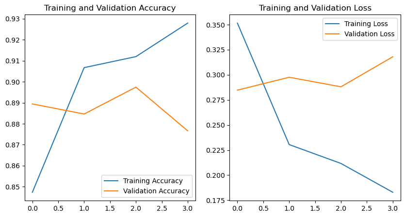

```python
plot(dense_history)
```

```
              precision    recall  f1-score   support

           0       0.87      0.96      0.92       267
           1       0.99      0.95      0.97       773

    accuracy                           0.95      1040
   macro avg       0.93      0.96      0.94      1040
weighted avg       0.96      0.95      0.96      1040
```

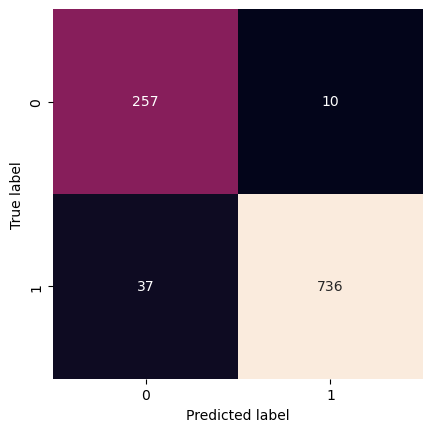

```python
dense_pred =[]
for image in test_data.image_path:#using test data
    dense_pred.append(predict(image , densenet_model));

final_dense_pred  = np.argmax(dense_pred , axis=-1);
actual_label = test_data['label']

print(classification_report(actual_label, final_dense_pred))
matrix=confusion_matrix(actual_label, final_dense_pred)
sns.heatmap(matrix,square=True, annot=True, fmt='d', cbar=False,
            xticklabels=['0', '1'],
            yticklabels=['0', '1'])
plt.xlabel('Predicted label')
plt.ylabel('True label');
```

```python
def compare_histories(vgg_history, dense_history):
    plt.figure(figsize=(16, 6))

    # Plot Training Accuracy
    plt.subplot(1, 2, 1)
    plt.plot(vgg_history.history['accuracy'], label='VGG16 Training Accuracy')
    plt.plot(dense_history.history['accuracy'], label='DenseNet Training Accuracy')
    plt.plot(vgg_history.history['val_accuracy'], label='VGG16 Validation Accuracy')
    plt.plot(dense_history.history['val_accuracy'], label='DenseNet Validation Accuracy')
    plt.title('Training and Validation Accuracy Comparison')
    plt.xlabel('Epoch')
    plt.ylabel('Accuracy')
    plt.legend()

    # Plot Training Loss
    plt.subplot(1, 2, 2)
    plt.plot(vgg_history.history['loss'], label='VGG16 Training Loss')
    plt.plot(dense_history.history['loss'], label='DenseNet Training Loss')
    plt.plot(vgg_history.history['val_loss'], label='VGG16 Validation Loss')
    plt.plot(dense_history.history['val_loss'], label='DenseNet Validation Loss')
    plt.title('Training and Validation Loss Comparison')
    plt.xlabel('Epoch')
    plt.ylabel('Loss')
    plt.legend()

    plt.show()
```

[figure not shown]

```python
# Call the function with the history objects
compare_histories(vgg_history, dense_history)
```

**Training Accuracy:** Both models show a similar trend in training accuracy, with DenseNet having a slightly higher accuracy than VGG16. The training accuracy is increasing for both models, which is a positive sign.

**Training Loss:** Both models show a decreasing trend in training loss, with DenseNet having a slightly lower loss compared to VGG16. This is consistent with the increase in training accuracy.

**Model Performance:** From this plot, DenseNet seems to be performing slightly better than VGG16 in terms of both accuracy and loss on the given dataset.

-**Input Layer:** Takes an input image of a fixed size (224 x 224 x 3).

-**Convolutional Layers:** Contains 19 weight layers - 16 convolutional layers and 3 fully connected layers.

-**Convolutional Blocks:** Organized into five blocks, each containing two or three convolutional layers followed by a max-pooling layer.

-**Fully Connected Layers:** Three fully connected layers of 4096, 4096, and 1000 nodes, respectively. The final layer has a softmax activation function, outputting 1000 probabilities corresponding to the 1000 ImageNet classes.

-**Activation Function:** ReLU (Rectified Linear Activation) is used after each convolution operation.

```python
from tensorflow.keras.applications.vgg19 import VGG19
base_model = VGG19(weights = 'imagenet', include_top = False, input_shape = (224, 224, 3))
tf.keras.backend.clear_session()

for layer in base.layers:
    layer.trainable = False

vgg_model1 = Sequential()
vgg_model1.add(base)
vgg_model1.add(GlobalAveragePooling2D())
vgg_model1.add(BatchNormalization())
vgg_model1.add(Dense(256, activation='relu'))
vgg_model1.add(Dropout(0.5))
vgg_model1.add(BatchNormalization())
vgg_model1.add(Dense(128, activation='relu'))
vgg_model1.add(Dropout(0.5))
vgg_model1.add(Dense(2, activation='softmax'))

vgg_model1.summary()
```

```
Model: "sequential"
_________________________________________________________________
 Layer (type)                Output Shape              Param #
=================================================================
 densenet169 (Functional)    (None, 7, 7, 1664)        12642880

 global_average_pooling2d (G  (None, 1664)             0
 lobalAveragePooling2D)

 batch_normalization (BatchN  (None, 1664)             6656
 ormalization)

 dense (Dense)               (None, 256)               426240

 dropout (Dropout)           (None, 256)               0

 batch_normalization_1 (Batc  (None, 256)              1024
 hNormalization)

 dense_1 (Dense)             (None, 128)               32896

 dropout_1 (Dropout)         (None, 128)               0

 dense_2 (Dense)             (None, 2)                 258

=================================================================
Total params: 13,109,954
Trainable params: 463,234
Non-trainable params: 12,646,720
_________________________________________________________________
```

```python
from tensorflow.keras.callbacks import EarlyStopping
train_gen, val_gen = gen()

optm = Adam(lr=0.0001)
vgg_model1.compile(loss='binary_crossentropy', optimizer=optm,
                  metrics=['accuracy'])

EarlyStopping = EarlyStopping(monitor='val_loss',
                              min_delta=.0001,
                              patience=3,
                              verbose=1,
                              mode='auto',
                              baseline=None,
                              restore_best_weights=True)

model_save = ModelCheckpoint('./vgg19_model.h5',
                             save_best_only = True,
                             save_weights_only = False,
                             monitor = 'val_loss',
                             mode = 'min', verbose = 1)


vgg_history1 = vgg_model1.fit(train_gen,
                             steps_per_epoch = train_gen.samples // BATCH_SIZE,
                             epochs = 10,
                             validation_data = val_gen,
                             callbacks=[EarlyStopping, model_save],
                             class_weight = class_weights)
```

```
Found 4192 validated image filenames.
Found 624 validated image filenames.
```

```
WARNING:absl:`lr` is deprecated, please use `learning_rate` instead, or use the legacy optimizer, e.g.,tf.keras.optimizers.legacy.Adam.
```

```
Epoch 1: val_loss improved from inf to 0.27500, saving model to .\vgg19_model.h5
Epoch 2: val_loss improved from 0.27500 to 0.23641, saving model to .\vgg19_model.h5
Epoch 3: val_loss did not improve from 0.23641
Epoch 4: val_loss did not improve from 0.23641

Epoch 5: val_loss did not improve from 0.23641
Epoch 5: early stopping
```

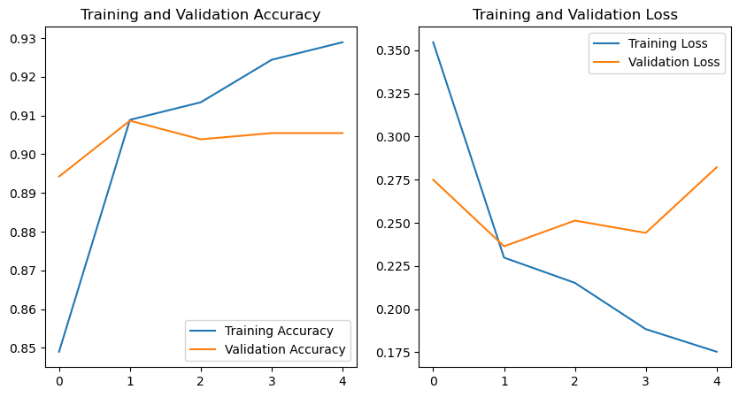

```python
plot(vgg_history1)
```

```python
print(vgg_history1.history['val_accuracy'][-3])
print(vgg_history1.history['val_loss'][-3])
```

```
0.9038461446762085
0.2513088881969452
```

```python
from PIL import Image
def predict(image_path, model):
    im = cv2.imread(image_path)
    test_image = np.asarray(im)
    processed_test_image = process_image(test_image)
    processed_test_image = np.expand_dims(processed_test_image, axis = 0)

    ps = model.predict(processed_test_image);
    return ps

def process_image(image):
    image = tf.cast(image , tf.float32)
    image = tf.image.resize(image , (224 , 224))
    image = image/255
    image = image.numpy()
    return image
```

```
              precision    recall  f1-score   support

           0       0.87      0.97      0.92       267
           1       0.99      0.95      0.97       773

    accuracy                           0.96      1040
   macro avg       0.93      0.96      0.94      1040
weighted avg       0.96      0.96      0.96      1040
```

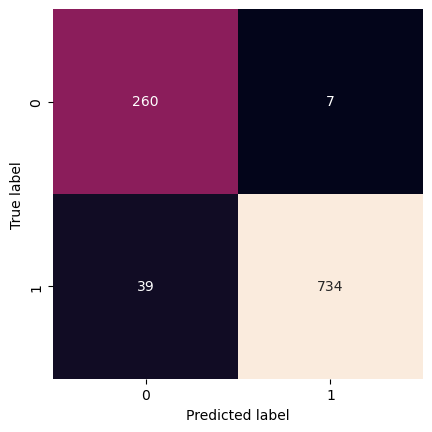

```python
vgg_pred =[]
for image in test_data.image_path:
    vgg_pred.append(predict(image , vgg_model1))

final_vgg_pred  = np.argmax(vgg_pred , axis=-1)
actual_label = test_data['label']

print(classification_report(actual_label, final_vgg_pred))
matrix=confusion_matrix(actual_label, final_vgg_pred)
sns.heatmap(matrix,square=True, annot=True, fmt='d', cbar=False,
            xticklabels=['0', '1'],
            yticklabels=['0', '1'])
plt.xlabel('Predicted label')
plt.ylabel('True label');
```

### InceptionV3

```python
from tensorflow.keras.applications import InceptionV3
base = InceptionV3(weights='imagenet', include_top=False, input_shape=(224, 224, 3))


for layer in base.layers:
    layer.trainable = False


x = GlobalAveragePooling2D()(base.output)
x = Dense(128, activation='relu')(x)
x = Dropout(0.5)(x)
x = Dense(128, activation='relu')(x)
x = Dropout(0.5)(x)
output = Dense(2, activation='softmax')(x)


incep_model = Model(inputs=base.input, outputs=output)


incep_model.summary()
```

```
Model: "model"
__________________________________________________________________________________________________
 Layer (type)                   Output Shape         Param #     Connected to
==================================================================================================
 input_1 (InputLayer)           [(None, 224, 224, 3  0           []
                                )]

 conv2d (Conv2D)                (None, 111, 111, 32  864         ['input_1[0][0]']
                                )

 batch_normalization_2 (BatchNo  (None, 111, 111, 32  96         ['conv2d[0][0]']
 rmalization)                   )

 activation (Activation)        (None, 111, 111, 32  0           ['batch_normalization_2[0][0]']
                                )

 conv2d_1 (Conv2D)              (None, 109, 109, 32  9216        ['activation[0][0]']
                                )

 batch_normalization_3 (BatchNo  (None, 109, 109, 32  96         ['conv2d_1[0][0]']
 rmalization)                   )

 activation_1 (Activation)      (None, 109, 109, 32  0           ['batch_normalization_3[0][0]']
                                )

 conv2d_2 (Conv2D)              (None, 109, 109, 64  18432       ['activation_1[0][0]']
                                )

 batch_normalization_4 (BatchNo  (None, 109, 109, 64  192        ['conv2d_2[0][0]']
 rmalization)                   )

 activation_2 (Activation)      (None, 109, 109, 64  0           ['batch_normalization_4[0][0]']
                                )

 max_pooling2d (MaxPooling2D)   (None, 54, 54, 64)   0           ['activation_2[0][0]']

 conv2d_3 (Conv2D)              (None, 54, 54, 80)   5120        ['max_pooling2d[0][0]']

 batch_normalization_5 (BatchNo  (None, 54, 54, 80)  240         ['conv2d_3[0][0]']
 rmalization)
```

[output cut: 735 more lines]

```
                                                                 ]']

 dropout_2 (Dropout)            (None, 128)          0           ['dense_3[0][0]']

 dense_4 (Dense)                (None, 128)          16512       ['dropout_2[0][0]']

 dropout_3 (Dropout)            (None, 128)          0           ['dense_4[0][0]']

 dense_5 (Dense)                (None, 2)            258         ['dropout_3[0][0]']

==================================================================================================
Total params: 22,081,826
Trainable params: 279,042
Non-trainable params: 21,802,784
__________________________________________________________________________________________________
```

```python
from tensorflow.keras.optimizers import Adam
from tensorflow.keras.callbacks import EarlyStopping

train_gen, val_gen = gen()

optm = Adam(lr=0.0001)
incep_model.compile(loss='binary_crossentropy', optimizer=optm,
                       metrics=['accuracy'])

early_stopping = EarlyStopping(monitor='val_loss',
                               min_delta=0.0001,
                               patience=3,
                               verbose=1,
                               mode='auto',
                               restore_best_weights=True)
model_save = ModelCheckpoint('./incep.h5',
                             save_best_only = True,
                             save_weights_only = False,
                             monitor = 'val_loss',
                             mode = 'min', verbose = 1)

incep_history = incep_model.fit(train_gen,
                                   steps_per_epoch=train_gen.samples // BATCH_SIZE,
                                   epochs=10,
                                   validation_data=val_gen,
                                   callbacks=[early_stopping])
```

```
Found 4192 validated image filenames.
Found 624 validated image filenames.
```

```
WARNING:absl:`lr` is deprecated, please use `learning_rate` instead, or use the legacy optimizer, e.g.,tf.keras.optimizers.legacy.Adam.
```

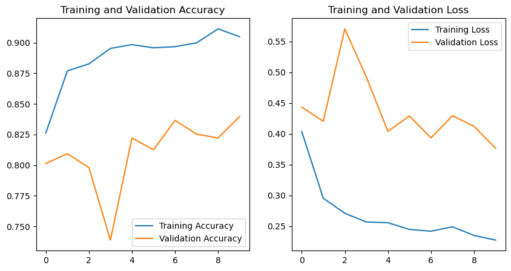

```python
plot(incep_history)
```

```python
print(incep_history.history['val_accuracy'][-3])
print(incep_history.history['val_loss'][-3])
```

```
0.8253205418586731
0.42936012148857117
```

```
              precision    recall  f1-score   support

           0       0.81      0.93      0.86       267
           1       0.97      0.92      0.95       773

    accuracy                           0.93      1040
   macro avg       0.89      0.93      0.91      1040
weighted avg       0.93      0.93      0.93      1040
```

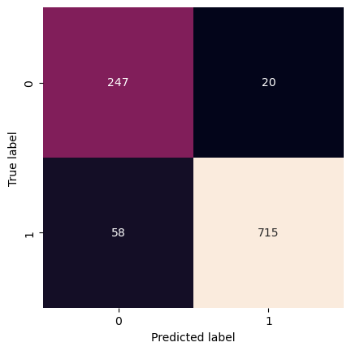

```python
incep_pred =[]
for image in test_data.image_path:#using test data
    incep_pred.append(predict(image , incep_model));

final_incep_pred  = np.argmax(incep_pred , axis=-1);
actual_label = test_data['label']

print(classification_report(actual_label, final_incep_pred))
matrix=confusion_matrix(actual_label, final_incep_pred)
sns.heatmap(matrix,square=True, annot=True, fmt='d', cbar=False,
            xticklabels=['0', '1'],
            yticklabels=['0', '1'])
plt.xlabel('Predicted label')
plt.ylabel('True label');
```

```python
def compare_histories(vgg_history, dense_history):
    plt.figure(figsize=(16, 6))

    # Plot Training Accuracy
    plt.subplot(1, 2, 1)
    plt.plot(vgg_history1.history['accuracy'], label='VGG19 Training Accuracy')
    plt.plot(dense_history.history['accuracy'], label='DenseNet Training Accuracy')
    plt.plot(vgg_history1.history['val_accuracy'], label='VGG19 Validation Accuracy')
    plt.plot(dense_history.history['val_accuracy'], label='DenseNet Validation Accuracy')
    plt.title('Training and Validation Accuracy Comparison')
    plt.xlabel('Epoch')
    plt.ylabel('Accuracy')
    plt.legend()

    # Plot Training Loss
    plt.subplot(1, 2, 2)
    plt.plot(vgg_history1.history['loss'], label='VGG19 Training Loss')
    plt.plot(dense_history.history['loss'], label='DenseNet Training Loss')
    plt.plot(vgg_history1.history['val_loss'], label='VGG19 Validation Loss')
    plt.plot(dense_history.history['val_loss'], label='DenseNet Validation Loss')
    plt.title('Training and Validation Loss Comparison')
    plt.xlabel('Epoch')
    plt.ylabel('Loss')
    plt.legend()

    plt.show()
```

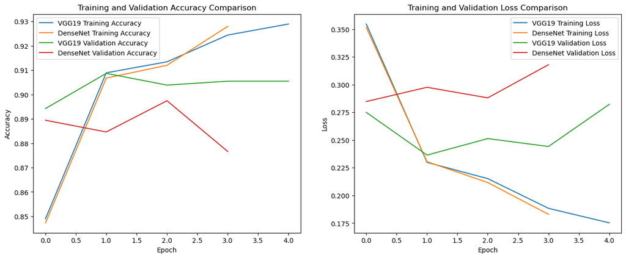

```python
compare_histories(vgg_history1,dense_history)
```

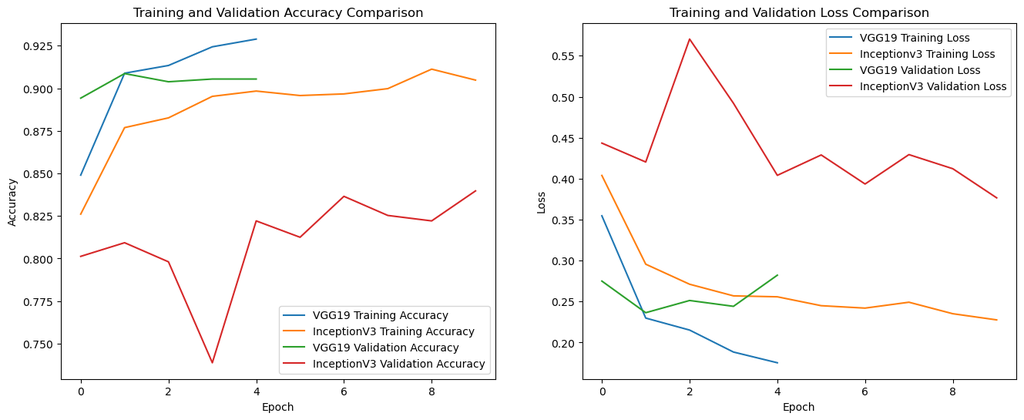

```python
def compare_histories(vgg_history, incep_history):
    plt.figure(figsize=(16, 6))

    # Plot Training Accuracy
    plt.subplot(1, 2, 1)
    plt.plot(vgg_history1.history['accuracy'], label='VGG19 Training Accuracy')
    plt.plot(incep_history.history['accuracy'], label='InceptionV3 Training Accuracy')
    plt.plot(vgg_history1.history['val_accuracy'], label='VGG19 Validation Accuracy')
    plt.plot(incep_history.history['val_accuracy'], label='InceptionV3 Validation Accuracy')
    plt.title('Training and Validation Accuracy Comparison')
    plt.xlabel('Epoch')
    plt.ylabel('Accuracy')
    plt.legend()

    # Plot Training Loss
    plt.subplot(1, 2, 2)
    plt.plot(vgg_history1.history['loss'], label='VGG19 Training Loss')
    plt.plot(incep_history.history['loss'], label='Inceptionv3 Training Loss')
    plt.plot(vgg_history1.history['val_loss'], label='VGG19 Validation Loss')
    plt.plot(incep_history.history['val_loss'], label='InceptionV3 Validation Loss')
    plt.title('Training and Validation Loss Comparison')
    plt.xlabel('Epoch')
    plt.ylabel('Loss')
    plt.legend()

    plt.show()
compare_histories(vgg_history1,incep_history)
```

```python
from tensorflow.keras.applications.xception import Xception
base = Xception(weights='imagenet', include_top=False, input_shape=(224, 224, 3))


for layer in base.layers:
    layer.trainable = False


x = GlobalAveragePooling2D()(base.output)
x = Dense(128, activation='relu')(x)
x = Dropout(0.5)(x)
x = Dense(128, activation='relu')(x)
x = Dropout(0.5)(x)
output = Dense(2, activation='softmax')(x)


xcep_model = Model(inputs=base.input, outputs=output)


xcep_model.summary()
```

```
Model: "model_1"
__________________________________________________________________________________________________
 Layer (type)                   Output Shape         Param #     Connected to
==================================================================================================
 input_2 (InputLayer)           [(None, 224, 224, 3  0           []
                                )]

 block1_conv1 (Conv2D)          (None, 111, 111, 32  864         ['input_2[0][0]']
                                )

 block1_conv1_bn (BatchNormaliz  (None, 111, 111, 32  128        ['block1_conv1[0][0]']
 ation)                         )

 block1_conv1_act (Activation)  (None, 111, 111, 32  0           ['block1_conv1_bn[0][0]']
                                )

 block1_conv2 (Conv2D)          (None, 109, 109, 64  18432       ['block1_conv1_act[0][0]']
                                )

 block1_conv2_bn (BatchNormaliz  (None, 109, 109, 64  256        ['block1_conv2[0][0]']
 ation)                         )

 block1_conv2_act (Activation)  (None, 109, 109, 64  0           ['block1_conv2_bn[0][0]']
                                )

 block2_sepconv1 (SeparableConv  (None, 109, 109, 12  8768       ['block1_conv2_act[0][0]']
 2D)                            8)

 block2_sepconv1_bn (BatchNorma  (None, 109, 109, 12  512        ['block2_sepconv1[0][0]']
 lization)                      8)

 block2_sepconv2_act (Activatio  (None, 109, 109, 12  0          ['block2_sepconv1_bn[0][0]']
 n)                             8)

 block2_sepconv2 (SeparableConv  (None, 109, 109, 12  17536      ['block2_sepconv2_act[0][0]']
 2D)                            8)

 block2_sepconv2_bn (BatchNorma  (None, 109, 109, 12  512        ['block2_sepconv2[0][0]']
 lization)                      8)

```

[output cut: 356 more lines]

```
                                                                 ]']

 dropout_4 (Dropout)            (None, 128)          0           ['dense_6[0][0]']

 dense_7 (Dense)                (None, 128)          16512       ['dropout_4[0][0]']

 dropout_5 (Dropout)            (None, 128)          0           ['dense_7[0][0]']

 dense_8 (Dense)                (None, 2)            258         ['dropout_5[0][0]']

==================================================================================================
Total params: 21,140,522
Trainable params: 279,042
Non-trainable params: 20,861,480
__________________________________________________________________________________________________
```

```python
from tensorflow.keras.optimizers import Adam
from tensorflow.keras.callbacks import EarlyStopping

train_gen, val_gen = gen()

optm = Adam(lr=0.0001)
xcep_model.compile(loss='binary_crossentropy', optimizer=optm,
                       metrics=['accuracy'])

early_stopping = EarlyStopping(monitor='val_loss',
                               min_delta=0.0001,
                               patience=3,
                               verbose=1,
                               mode='auto',
                               restore_best_weights=True)
model_save = ModelCheckpoint('./xcep.h5',
                             save_best_only = True,
                             save_weights_only = False,
                             monitor = 'val_loss',
                             mode = 'min', verbose = 1)

xcep_history = xcep_model.fit(train_gen,
                                   steps_per_epoch=train_gen.samples // BATCH_SIZE,
                                   epochs=10,
                                   validation_data=val_gen,
                                   callbacks=[early_stopping])
```

```
Found 4192 validated image filenames.
Found 624 validated image filenames.
```

```
WARNING:absl:`lr` is deprecated, please use `learning_rate` instead, or use the legacy optimizer, e.g.,tf.keras.optimizers.legacy.Adam.
```

```python
print(xcep_history.history['val_accuracy'][-3])
print(xcep_history.history['val_loss'][-3])
```

```
0.8669871687889099
0.3060743510723114
```

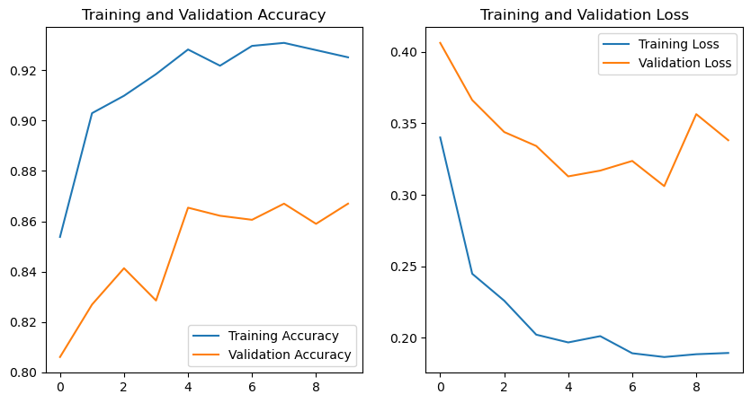

```python
plot(xcep_history)
```

```
              precision    recall  f1-score   support

           0       0.86      0.94      0.89       267
           1       0.98      0.95      0.96       773

    accuracy                           0.94      1040
   macro avg       0.92      0.94      0.93      1040
weighted avg       0.95      0.94      0.94      1040
```

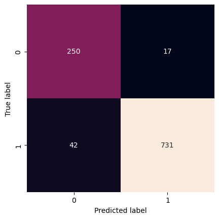

```python
xcep_pred =[]
for image in test_data.image_path:#using test data
    xcep_pred.append(predict(image , xcep_model));

final_xcep_pred  = np.argmax(xcep_pred , axis=-1);
actual_label = test_data['label']

print(classification_report(actual_label, final_xcep_pred))
matrix=confusion_matrix(actual_label, final_xcep_pred)
sns.heatmap(matrix,square=True, annot=True, fmt='d', cbar=False,
            xticklabels=['0', '1'],
            yticklabels=['0', '1'])
plt.xlabel('Predicted label')
plt.ylabel('True label');
```

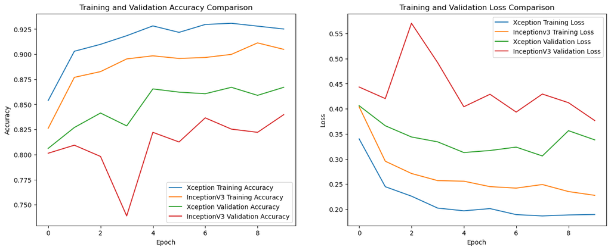

```python
def compare_histories(xcep_history, incep_history):
    plt.figure(figsize=(16, 6))

    # Plot Training Accuracy
    plt.subplot(1, 2, 1)
    plt.plot(xcep_history.history['accuracy'], label='Xception Training Accuracy')
    plt.plot(incep_history.history['accuracy'], label='InceptionV3 Training Accuracy')
    plt.plot(xcep_history.history['val_accuracy'], label='Xception Validation Accuracy')
    plt.plot(incep_history.history['val_accuracy'], label='InceptionV3 Validation Accuracy')
    plt.title('Training and Validation Accuracy Comparison')
    plt.xlabel('Epoch')
    plt.ylabel('Accuracy')
    plt.legend()

    # Plot Training Loss
    plt.subplot(1, 2, 2)
    plt.plot(xcep_history.history['loss'], label='Xception Training Loss')
    plt.plot(incep_history.history['loss'], label='Inceptionv3 Training Loss')
    plt.plot(xcep_history.history['val_loss'], label='Xception Validation Loss')
    plt.plot(incep_history.history['val_loss'], label='InceptionV3 Validation Loss')
    plt.title('Training and Validation Loss Comparison')
    plt.xlabel('Epoch')
    plt.ylabel('Loss')
    plt.legend()

    plt.show()
compare_histories(xcep_history,incep_history)
```

### Summary

Both VGG16 and DenseNet169 have been used extensively in various computer vision tasks, such as object detection, image segmentation, and classification. While VGG16 is simpler and more straightforward, DenseNet's dense connections make it more parameter-efficient and enable it to capture more complex patterns.